# 1 Estou com sorte no baralho?

## 1.1 Objetivo

Introduzir os visitantes da mostra à ideia de medidas resumo, em específico as medidas de média, moda, mediana e amplitude.

## 1.2 Descrição

As medidas resumo correspondem a uma síntese do conjunto de dados observados. Elas nos auxiliam quando precisamos analisar o comportamento de uma quantidade grande de dados.

## 1.3 Construção

Para este experimento só é necessário um conjunto de cartas enumeradas.

## 1.4 Execução

A ideia do experimento é que cada aluno calculará uma das medidas resumo propostas para um certo conjunto de valores. O aluno que responder corretamente mais rápido ganha a brincadeira.

No início, cada aluno pode sortear uma medida para calcular ou uma medida é sorteada para todos.

Logo após, são distribuídas 4 cartas com a face virada para baixo para os alunos. Essas cartas fornecerão o conjunto de valores que cada aluno irá se basear para calcular a medida.

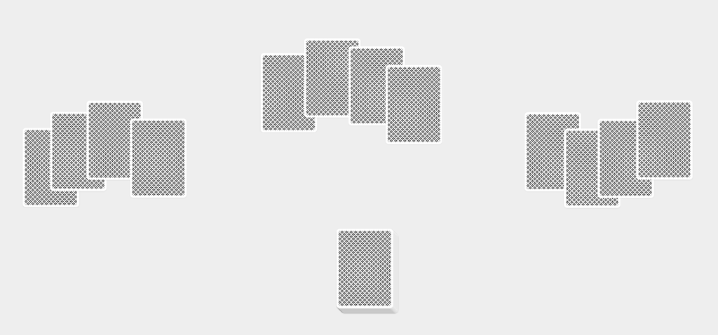

Após todos estarem prontos, o sinal é dado e quem calcular mais rápido ganha.

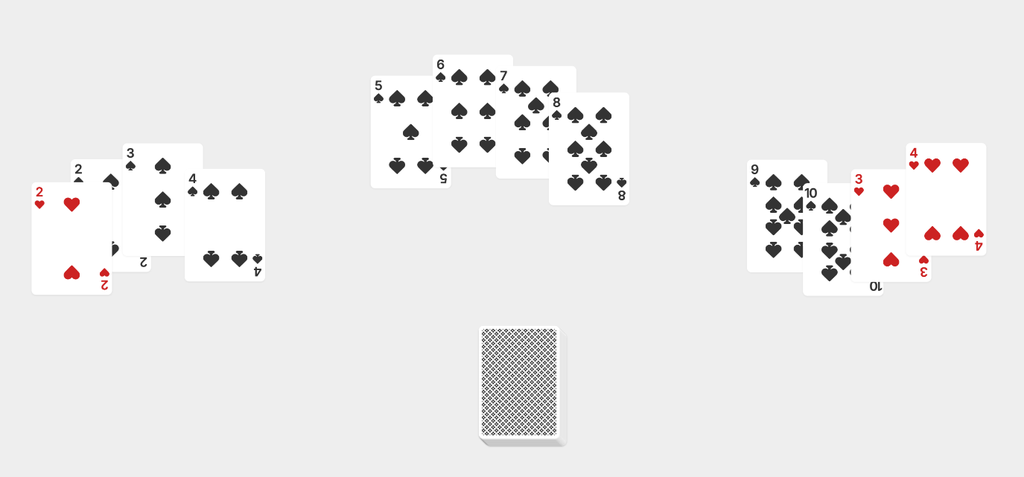

Observações:

1. O número de 4 cartas por aluno é uma sugestão; o valor pode ser alterado, caso necessário.
2. Para facilitar os cálculos, cartas podem ser removidas do jogo. Por exemplo, remover números ímpares.

## 1.5 Teoria

Segue uma breve apresentação das medidas presentes nesse experimento

### 1.5.1 Média

Seja X o conjunto de valores $\scriptstyle \{x_1, x_2, \dots, x_n\}$, a média aritmetica de X, que será denotada por $\scriptstyle \bar{X}$, é definida

$$\bar{X} = \frac{\sum_{i=1}^n x_i}{n} = \frac{x_1 + x_2 + \dots + x_n}{n}$$
Ela é classificada como uma medida de tendência central.

### 1.5.2 Mediana

Seja X o conjunto de valores $\scriptstyle \{x_1, x_2, \dots, x_n\}$, onde $\scriptstyle x_1 \leq x_2 \leq x_3 \leq \dots \leq x_n$, a **mediana** de X, que será denotada por $\scriptstyle \text{Med}(X)$, é definida como sendo o valor que está no centro, ou seja,

$$\text{Med}(X) = x_{[(n + 1)/2]}$$
quando n, número de valores em X, é impar, e

$$\text{Med}(X) = \frac{x_{[n/2]}+x_{[(n/2) + 1]}}{2}$$
quando n é par. Ela é classificada como uma medida de tendência central.

### 1.5.3 Amplitude

Seja X o conjunto de valores $\scriptstyle \{x_1, x_2, \dots, x_n\}$, a **amplitude** de $\scriptstyle X$, que será denotada $\scriptstyle \text{Amp}(X)$, é definida como sendo a distancia entre os valores extremos de X, ou seja,

$${\text{Amp}(X)} = X_{(n)} - X_{(1)}$$
Onde, $\scriptstyle X_{(n)}$ representa o valor que é maior ou igual a todos os outros valores em X e $\scriptstyle X_{(1)}$ representa o valor que é menor ou igual a todos os outros valores em X. Ela é classificada como uma medida de dispersão.

### 1.5.4 Moda

A **moda** de X é o valor ou valores, se houver candidatos equiparados, tais que apresentam-se com uma frequência maior que os outros, sendo o conjunto podendo ser amodal quando não possui moda, unimodal quando possui somente uma moda, bimodal quando possui duas modas e multimodal quando possui mais de duas modas. Ela é classificada como uma medida de tendência central.

## 1.6 Aplicação prática

As medidas de tendência central, como a média, a mediana e a moda, ajudam a resumir um conjunto de dados em um único valor representativo, indicando onde a maioria dos dados está concentrada.

Por outro lado, as medidas de dispersão, como o desvio padrão, a variância e a amplitude, fornecem informações sobre o quão dispersos ou variáveis são os dados em torno da medida de tendência central. Isso é importante para entender a dispersão dos dados e a variabilidade dentro do conjunto, o que pode afetar interpretações e tomadas de decisão.

Em resumo, essas medidas são úteis porque fornecem uma compreensão concisa e quantitativa da distribuição dos dados, permitindo análises e comparações do comportamento dos fenômenos em estudo.

## 1.7 Referências e leituras complementares

**Flavia, Ezequiel, Nei, Vanessa, e Alexandre**. “MEDIDAS DE POSIÇÃO E DISPERSÃO”, disponível em: https://impa.br/wp-content/uploads/2019/07/PAPMEM_julho_2019_Nocoes-de-Estatistica_2_parte_Flavia.pdf

**Anirudh V. S. Ruhil**. “Central Tendency and Dispersion”, disponível em: https://people.ohio.edu/ruhil/statsbook/meansd.html